# Introducing `Gen3-PokeGAN`

The designs in Pokemon games shifted styles over the years. With the release of Pokemon Ruby and Sapphire in 2002 (i.e., Generation 3 | Gen3), they used a characteristically iconic `pixel style` to fit the constraints of the Gameboy Advance. As new consoles were released, the designs began shifting toward a `3D model style`. Since 2002, many new Pokemon have been created, but never been officially drawn in the iconic `pixel style`.

[figure not shown]

Generative AI Image models such as DALL-E are able to produce quality images from text alone, but the goal of this project is to be able to receive an image as an input (i.e., `3D model style` Pokemon) and generate an output (i.e., `pixel style` Pokemon). By creating such a model, new pokemon can be reimagined in the iconic `pixel style`. After exploring different computer vision machine learning frameworks that exist, I found one that would be suitable for this task called CycleGAN.

# CycleGAN Architecture

The proposed model architecture leverages the CycleGAN framework, as introduced in the seminal paper "Unpaired Image-to-Image Translation using Cycle-Consistent Adversarial Networks" by Zhu et al. (2017). This architecture enables the translation of images from one domain to another without requiring paired examples during training, making it particularly suitable for our task of generating pixel art images from 3D model inputs.

The primary objective of the model architecture is to establish a mapping between two image domains: Domain A, representing the `3D model style` of Pokemon, and Domain B, representing the `pixel style`. By learning this mapping, the model can generate pixel art-style images from 3D model inputs, thereby allowing the reimagining of Pokemon in the iconic pixel style.

## Generative Adversarial Networks

In order to create this mapping between the two image domains, a `generator` model would need to be trained so that the image outputs are indistinguishable from the actual `pixel style` pokemon for the best results. When training all machine learning models, a `loss` has to be calculated during the training procedure to update the weights for better results through backpropagation. The way we are going to improve our `generator`s performance is by creating a competing `Discriminator` (i.e., Adversarial Judge) model that is going to judge whether the `generator's` output is fake (i.e., generated) or an actual `pixel style` sprite from the training dataset.

During training, the generator tries to generate samples that are indistinguishable from real data, while the discriminator aims to differentiate between real and fake samples accurately. This process leads to a competitive game where the generator improves its ability to generate realistic samples as the discriminator becomes more discerning. Through this competition, our `Generator` is going to learn how to create an output that is most similar to the iconic `pixel style` we are trying to capture in this project.

### Generators: Dual Mapping Functions

The heart of the Gen3-PokeGAN resides in its dual mapping functions, embodied by two generator networks: G(X->Y) and G(Y->X). These generators are the artists translating visions between dimensions, taking a 3D model style Pokémon (X) and rendering it in the nostalgic pixel style (Y), and vice versa. Unlike typical transformations, these mappings are unpaired; no direct correspondence between individual images in the domains exists. This is where the magic of CycleGAN shines, empowering the model to learn these styles implicitly through a cycle consistency loss.

[figure not shown]

In practice, the G(X->Y) network absorbs the intricate details of 3D models, distilling the essence down into pixel art, capturing the soul of Gen3 in every generated sprite. Meanwhile, G(Y->X) performs the reverse, envisioning what these pixel sprites might look like had they been crafted for the 3D realm. This cyclical process not only enhances the model's ability to cross-translate with fidelity but also imbues it with a deep understanding of the stylistic nuances that define both realms of Pokémon.

### Discriminators: Adversarial Judges

Balancing the creative force of the generators are the discerning eyes of the discriminators, Dx(Judge X) and Dy(Judge Y). They serve as the adjudicators of authenticity, tasked with the critical role of discerning the generated images from the real. The discriminator Dx(Judge X) scrutinizes the authenticity of 3D model outputs, while Dy(Judge Y) evaluates the pixel style sprites. Their goal is to guide the generators towards perfection, challenging them to create images that can pass as genuine to even the most astute observer.

[figure not shown]

The discriminators' judgments provide a feedback loop essential to adversarial training. When a discriminator flags a generated image as fake, it sends a signal back to the generator, pressing it to improve. It's an iterative dance of creation and critique, pushing the boundaries of generative capabilities. As the discriminators sharpen their acuity, the generators rise to meet the challenge, resulting in a harmonious escalation of skill — the essence of adversarial learning. This elegant symphony of competition and cooperation is what enables Gen3-PokeGAN to render Pokémon in styles that captivate both the new-age aficionado and the retro enthusiast alike.

# Dataset and Pre-Processing

When training computer vision models, formatting the training and validation data is extremely important for effective training. The original CycleGAN paper used approximately 1,000 images within their two image domains (e.g., zebras to horses) that were 256 x 256 pixels. One obstacle for this project is that in 2002 when the gen3 pokemon games were released, there were only 386 unique pokemon in the `pixel style`. Conversely, for the `3D model style` there are 1,025 unique pokemon available which fits the dataset size used in the original paper. For this reason, I ran two versions of the models training with two datasets which I will elaborate.

For both model training sessions, the `3D model style` dataset is the same. It is extracted from the ProjectPokemon website (link: https://projectpokemon.org/home/docs/spriteindex_148/home-sprites-gen-1-r128/) which contains all of the unique pokemon, and their variant forms. It is important to note that these images are .pngs and are 512 x 512 pixels.

For the `pixel style` dataset, the first training set with the original 386 pokemon were extracted from Pokencyclopedia.info (link: https://www.pokencyclopedia.info/en/index.php?id=sprites/gen3/spr_ruby-sapphire). For the second dataset that includes all of 1,025 pokemon and their variant forms, I used the first 386 from the data source above, and for the remaining ones, they were extracted a fan-created pokemon game based on the gen3 pokemon games called Radical Red. In this game they drew the newer pokemon in the gen3 `pixel style` to now have a full dataset with all pokemon that currently exist. Since the fan-game is a modded version of the original game, both of the `pixel style` datasets are .png images that are 64 x 64 pixels.

## Image Formatting

When training a computer vision model like CycleGAN, both datasets have to match each other in pixel size and image formatting. I created a code snippet that is able to receive images from both image domains (i.e., 512 x 512 pixels from `3D model style` and 64 x 64 pixels from `pixel style`), and generate new images that are 256 x 256 pixels in RGB format for training.

```python
from PIL import Image
import os

def resize_and_save_images(source_dir, target_dir, size=(256, 256)):
    """
    Resizes all images in the source directory and saves them to the target directory.

    Parameters:
    - source_dir: Directory containing the original images.
    - target_dir: Directory where resized images will be saved.
    - size: Desired size of the resized images, defaults to (256, 256).
    """
    # Create the target directory if it does not exist
    if not os.path.exists(target_dir):
        os.makedirs(target_dir)

    # Resize each image in the source directory and save to the target directory
    for filename in os.listdir(source_dir):
        if filename.endswith(('.png', '.jpg', '.jpeg')):  # Check for common image file extensions
            img_path = os.path.join(source_dir, filename)
            img = Image.open(img_path).convert('RGB')  # Convert to RGB to ensure compatibility
            # Use Image.LANCZOS for high-quality downsampling
            img_resized = img.resize(size, Image.LANCZOS)

            # Define the path for the resized image
            resized_img_path = os.path.join(target_dir, filename)
            img_resized.save(resized_img_path)
            print(f"Resized and saved: {resized_img_path}")

base_dir = "pokemon_images"
source_dirs = ["3d", "pixel"]
target_dirs = ["3d_transformed", "pixel_transformed"]

# Iterate over the source and target directories to resize and save images
for source_subdir, target_subdir in zip(source_dirs, target_dirs):
    source_path = os.path.join(base_dir, source_subdir)
    target_path = os.path.join(base_dir, target_subdir)
    resize_and_save_images(source_path, target_path)

print("Image resizing and saving complete.")
```

After running this script, the image data between the `pixel style` and `3D model style` now has the same shape and characteristics as the horse-zebra dataset from the original CycleGAN paper (i.e., 256 x 256 pixels) allowing us to move to the next steps.

## Training and Validation Split

For complex neural network models such as CycleGAN, training and validation splits are very important to ensure that the model is not overfitting. The `Training` dataset is all of the data the model has access to during training to best update its parameters through backpropagation. Most neural network models are able to minimize the loss of the `Training` dataset with ease. However, the purpose of these models is to be able to generalize to input data the model has never been exposed to. This is where the `Validation` dataset comes into play because it feeds into the model images it has never seen.

Considering the risk of overfitting on the `Training` dataset, I decided to randomly assign pokemon by their pokedex number through a 80% `Training` and 20% `Validation` split. By doing this, we can ensure our model is being being assessed on a decent chunk of data that was unseen during its training. Here is the training and validation split for both datasets, respectively:

**First Training Set**

**Second Training Set**

- Total Validation Images: 215
- Total Training Images: 860

I labeled all of the pokemon images by their Pokedex number, and added decimals for variant forms (e.g., Deoxys 386.1 for attack form). Though the CycleGAN paper is training not based on 1-to-1 image mapping, to make sure that the `Training` dataset and the `Validation` dataset are truly separate, the code below makes sure that for each specific pokemon, it is either assigned to `Training` or `Validation` in a perfect 1-to-1 mapping.

```python
import os
import random
import shutil

def split_data(source_dir_2d, source_dir_3d, train_dir_2d, val_dir_2d, train_dir_3d, val_dir_3d, split_ratio=0.8):
    """Split the data into training and validation sets with 1-to-1 mapping."""
    print("Preparing directories...")
    os.makedirs(train_dir_2d, exist_ok=True)
    os.makedirs(val_dir_2d, exist_ok=True)
    os.makedirs(train_dir_3d, exist_ok=True)
    os.makedirs(val_dir_3d, exist_ok=True)

    print(f"Directories prepared for 2D: {train_dir_2d}, {val_dir_2d}")
    print(f"Directories prepared for 3D: {train_dir_3d}, {val_dir_3d}")

    # Get a list of all image filenames from one source directory
    try:
        filenames_2d = os.listdir(source_dir_2d)
        filenames_3d = os.listdir(source_dir_3d)
        filenames = list(set(filenames_2d).intersection(filenames_3d))
        if not filenames:
            print(f"No matching files found between 2D and 3D directories. Check if paths and files are correct.")
            return
        print(f"Found {len(filenames)} matching files between 2D and 3D source directories.")
    except FileNotFoundError as e:
        print(f"Directory not found: {str(e)}")
        return

    random.shuffle(filenames)
    num_train = int(len(filenames) * split_ratio)

    # Split and copy images
    train_count = 0
    val_count = 0
    for i, filename in enumerate(filenames):
        file_2d = os.path.join(source_dir_2d, filename)
        file_3d = os.path.join(source_dir_3d, filename)

        target_2d = os.path.join(train_dir_2d, filename) if i < num_train else os.path.join(val_dir_2d, filename)
        target_3d = os.path.join(train_dir_3d, filename) if i < num_train else os.path.join(val_dir_3d, filename)

        try:
            shutil.copyfile(file_2d, target_2d)
            shutil.copyfile(file_3d, target_3d)
            train_count += i < num_train
            val_count += i >= num_train
        except Exception as e:
            print(f"Error copying {filename}: {str(e)}")

    print(f"Number of files copied to 2D train directory: {train_count}")
    print(f"Number of files copied to 2D val directory: {val_count}")
    print(f"Number of files copied to 3D train directory: {train_count}")
    print(f"Number of files copied to 3D val directory: {val_count}")

# Set the directory paths and perform operations
source_base_dir = "/content/drive/MyDrive/Pokemon_Gen3_Sprites/PixelCycleGan/Pokemon_Images"
train_val_base_dir = "/content/drive/MyDrive/Pokemon_Gen3_Sprites/PixelCycleGan/data"

# Paths setup
pixel_dataset_dir = os.path.join(source_base_dir, "pixel_dataset")
threeD_dataset_dir = os.path.join(source_base_dir, "3d_dataset")
pixel_train_dir = os.path.join(train_val_base_dir, "train", "sprite_pokemon")
pixel_val_dir = os.path.join(train_val_base_dir, "val", "sprite_pokemon")
threeD_train_dir = os.path.join(train_val_base_dir, "train", "3D_pokemon")
threeD_val_dir = os.path.join(train_val_base_dir, "val", "3D_pokemon")

# Perform synchronized splitting
split_data(pixel_dataset_dir, threeD_dataset_dir, pixel_train_dir, pixel_val_dir, threeD_train_dir, threeD_val_dir)

print("Data splitting complete.")

#### OUTPUT ####

# Preparing directories...
# Directories prepared for 2D: /content/drive/MyDrive/Pokemon_Gen3_Sprites/PixelCycleGan/data/train/sprite_pokemon, /content/drive/MyDrive/Pokemon_Gen3_Sprites/PixelCycleGan/data/val/sprite_pokemon
# Directories prepared for 3D: /content/drive/MyDrive/Pokemon_Gen3_Sprites/PixelCycleGan/data/train/3D_pokemon, /content/drive/MyDrive/Pokemon_Gen3_Sprites/PixelCycleGan/data/val/3D_pokemon
# Found 1075 matching files between 2D and 3D source directories.
# Number of files copied to 2D train directory: 860
# Number of files copied to 2D val directory: 215
# Number of files copied to 3D train directory: 860
# Number of files copied to 3D val directory: 215
# Data splitting complete.
```

Now that we have done all of the model pre-processing and training/validation splitting, the final data has both the `3D model style` and `pixel style` images as 256 x 256 .png photos in RGB colors. In order to confirm that all of the data is ready for training, this code below is able to double check everything. It also displays images of the training and validation data with their shape as well for reference.

```
Folder Directory: data/train/sprite_pokemon
Total number of images: 860
Image shape: (256, 256)
```

[figure not shown]

```
Folder Directory: data/train/3D_pokemon
Total number of images: 860
Image shape: (256, 256)
```

[figure not shown]

```
Folder Directory: data/val/sprite_pokemon
Total number of images: 215
Image shape: (256, 256)
```

[figure not shown]

```
Folder Directory: data/val/3D_pokemon
Total number of images: 215
Image shape: (256, 256)
```

[figure not shown]

```python
import os
from PIL import Image
import matplotlib.pyplot as plt

data_dir = 'data'

# Define categories and types
data_types = ['train', 'val']
categories = ['sprite_pokemon', '3D_pokemon']

def print_and_display_specific_image(data_dir, data_types, categories):
    for data_type in data_types:
        for category in categories:
            category_path = os.path.join(data_dir, data_type, category)
            images = os.listdir(category_path)
            # Filter images based on the specific requirement
            if data_type == 'val':
                filtered_images = [img for img in images if "100" in img]
            elif data_type == 'train':
                filtered_images = [img for img in images if "117" in img]

            num_total_images = len(images)  # Total number of images in the folder
            num_filtered_images = len(filtered_images)  # Number of images after filtering
            if num_filtered_images > 0:
                # Use the first image from the filtered list
                first_image_path = os.path.join(category_path, filtered_images[0])
                with Image.open(first_image_path) as img:
                    img_shape = img.size  # (width, height)
                    # Print folder details
                    print(f"Folder Directory: {category_path}")
                    print(f"Total number of images: {num_total_images}")
                    print(f"Image shape: {img_shape}")
                    # Display the first image from the filtered list
                    plt.imshow(img)
                    plt.title(f"Filtered Image in {category} - {data_type}")
                    plt.axis('off')
                    plt.show()
            else:
                print(f"Folder Directory: {category_path}")
                print(f"Total number of images: {num_total_images}")
                print("No filtered images found.")

print_and_display_specific_image(data_dir, data_types, categories)
```

# Model Training

With all of the data pre-processing completed, we can move forward with the model training. Training neural network models are computationally heavy, so I used Google Colab Pro and trained it on their GPUs. The one that was used for my training sessions was the `V100 High RAM GPU`. Since the CycleGAN training is complex, the whole process has been captured in a series of Python files, which are loaded into Google Colab for training. Below, I add descriptions for the most pivotal python scripts so you understand what is happening under the hood during training. All of these are linked in the `Gen3-PokeGAN` Github repo linked here:

https://github.com/DataWithAlex/gen3-pokeGAN

- `generator_model.py` : Here a PyTorch module for the Generator of a CycleGAN is implemented. It comprises several convolutional blocks for down-sampling, residual blocks for feature transformation, and up-sampling blocks for spatial expansion. The Generator takes an input image and generates a transformed output image, aiming to convert 3D Pokémon images into sprite versions and vice versa. Additionally, a detailed test function demonstrates the shape transformations that occur at each stage of the Generator, elucidating the role of each component in the image transformation process.
- `discriminator_model.py` : Here a PyTorch module for the Discriminator of a CycleGAN is constructed. It includes a custom Block class for defining the basic building blocks of the discriminator network. The Discriminator class initializes the network with sequential layers, including convolutional layers followed by instance normalization and leaky ReLU activation. Additionally, a test function is provided to instantiate the discriminator and run a forward pass with random data, demonstrating the shape of the output tensor.
- `config.py` : Here are the centralized settings for CycleGAN training are defined. The file includes device configuration, dataset paths, hyperparameters such as learning rate and batch size, and scheduler configurations for adjusting learning rates during training. Additionally, functions are provided to update hyperparameters and scheduler parameters conveniently, facilitating hyperparameter tuning.
- `train.py` : Here the CycleGAN model undergoes training for transforming 3D model-style Pokémon images into pixel-style ones and vice versa. The script orchestrates the alternating training of discriminator and generator models, measuring image translation quality through loss functions like Mean Squared Error (MSE) and L1 loss. As each epoch progresses, model checkpoints are saved upon validation loss improvements, while training metrics are logged to monitor the training's progress in a file called `training_progress.csv`.

## Hyperparameter Tuning

For the CycleGAN model training, finding the correct hyperparameters are extremely important to ensure that everything is trained accordingly. This is a very challenging process because since we are training our model on Google Colab's `V100 High-RAM GPU`, it gets costly to run the model even a few times. However, with the incorrect hyperparameters, the model is going to train poorly.

For the CycleGAN model, what I found is that the `learning rate` was the most important hyper parameter to focus on. For instance, if it's too high, the model's weight updates become erratic, leading to instability. Conversely, if it's too low, training progress slows down, and the model may struggle to converge. Finding the right balance is key to effective parameter updates and stable training, ensuring optimal performance.

What I did was run different training sessions with different hyperparameters set. I looked at which hyperparameter values resulted in the lowest validation loss and looked closest to the `pixel style` pokemon from looking at specific outputs. I am going to report the most important training sessions below since so many were runned. If you would like to review all of the other training sessions, they can be found in various jupyter notebooks on the github page.

# Best Model Trained

After exploring many hyperparameter settings for both the first (i.e., partial dataset) training dataset and the second (i.e., full dataset), these were the best training sessions that resulted in the best results.

### First (i.e., Partial Dataset) Training and Results

```python
# Import config.py which specifies hyperparameter values for training optmization
import config

# Determining whether Model Weights should be Pre-Loaded and Saved
config.LOAD_MODEL = False
config.SAVE_MODEL = True

# The best Hyperparameters found through trial and error
config.LAMBDA_CYCLE=10.0
config.LEARNING_RATE=1e-4
config.NUM_EPOCHS=20

# Run the training script
%run train.py
```

```python
##########
# OUTPUT #
##########

100%|██████████| 273/273 [00:34<00:00,  7.81it/s, D_3D_loss=0.45, D_Sprite_loss=0.462, G_3D_loss=0.339, G_Sprite_loss=0.316, Sprite_fake=0.466, Sprite_real=0.532]
Epoch [0/20]
Training Loss: 4.187516895515142
Validation Loss: 3.958749771118164
G_Sprite Loss: 0.3164572705934336, G_3D Loss: 0.33890028063194216, D_Sprite Loss: 0.4622476354186788, D_3D Loss: 0.45041592490105403
Validation loss decreased to 3.958749771118164. Saving model...
=> Saving checkpoint
=> Saving checkpoint
=> Saving checkpoint
=> Saving checkpoint
100%|██████████| 273/273 [00:34<00:00,  7.88it/s, D_3D_loss=0.429, D_Sprite_loss=0.459, G_3D_loss=0.376, G_Sprite_loss=0.325, Sprite_fake=0.456, Sprite_real=0.529]
Epoch [1/20]
Training Loss: 3.2082760956261183
Validation Loss: 4.087966442108154
G_Sprite Loss: 0.3254064762548649, G_3D Loss: 0.3758958427460639, D_Sprite Loss: 0.45905314271266645, D_3D Loss: 0.4288905490558226
100%|██████████| 273/273 [00:34<00:00,  7.99it/s, D_3D_loss=0.4, D_Sprite_loss=0.454, G_3D_loss=0.415, G_Sprite_loss=0.335, Sprite_fake=0.452, Sprite_real=0.533]
Epoch [2/20]
Training Loss: 3.1523587170974676
Validation Loss: 3.594146966934204
G_Sprite Loss: 0.3352643167907065, G_3D Loss: 0.4153112182632471, D_Sprite Loss: 0.45417280347792655, D_3D Loss: 0.40031011135150224
Validation loss decreased to 3.594146966934204. Saving model...
=> Saving checkpoint
=> Saving checkpoint
=> Saving checkpoint
=> Saving checkpoint
......
......
Training continues till "Epoch [20/20]"
```

If you take a look at the output, you can see as the validation loss kept decreasing, it would prompt 4 lines of code `=> Saving Checkpoint`. What this is doing is that when the model increases in performance, it saves the checkpoints for both `generators` and `discriminators` so it could be used for deployment, or be loaded up for future training to start from the best parameters.

Seeing if the validation loss decreased isn't the only indicator if the model is improving, it is important to have a human look at how the model is generating images from input to see if it is working correctly. Below I have a code snippet that is loading the model weights from `gen_Sprite.pth.tar`. With this pre-loaded, we can have the model create a series of outputs based on inputs. For my training, I have three pokemon I use as standard input images, and generate their respective outputs alongside with the model training metrics.

Below I have added the code snippet that loads the model weights (e.g., `gen_Sprite.pth.tar`) to show the model outputs (this will later be used for deployment). Additionally, I am going to print out the model metrics so you can see how the first training session did in terms of performance.

```
Generated image saved: model_images/First_Model_Output/2.png
Generated image saved: model_images/First_Model_Output/3.png
Generated image saved: model_images/First_Model_Output/1.png
```

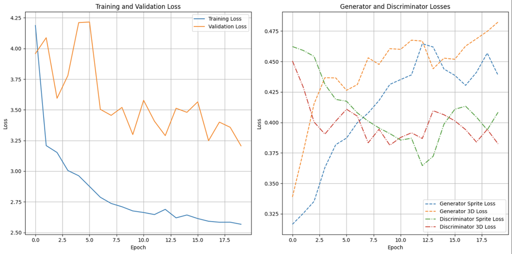

[figure not shown]

```python
from metrics import display_images_first_model
import os
import torch
from PIL import Image
from torchvision.transforms import transforms
from generator_model import Generator
from generator_model import quantize_image
from IPython.display import display

# Define input and output directories
input_dir = "model_images/Input_images"
output_dir = "model_images/First_Model_Output"

# Load the generator model
generator = Generator(img_channels=3, num_residuals=9)
generator.load_state_dict(torch.load('Best_Model_Weights/BEST_WEIGHTS/gen_Sprite.pth.tar', map_location='cpu')['state_dict'])
generator.eval()

# Define transformation
transform = transforms.Compose([
    transforms.Resize((256, 256)),  # Resize to the input of the model
    transforms.ToTensor(),  # Convert the image to a tensor
    transforms.Normalize([0.5, 0.5, 0.5], [0.5, 0.5, 0.5])  # Normalize the image
])

# Process each image in the input directory
for filename in os.listdir(input_dir):
    if filename.endswith(".png"):
        input_image_path = os.path.join(input_dir, filename)
        input_image = Image.open(input_image_path).convert('RGB')
        preprocessed_image = transform(input_image).unsqueeze(0)

        # Generate the image
        with torch.no_grad():
            generated_image = generator(preprocessed_image).squeeze(0)
            generated_image = (generated_image + 1) / 2

        # Convert tensor to image
        output_image = transforms.ToPILImage()(generated_image.cpu())
        output_image = quantize_image(output_image, block_size = 4)

        # Save the generated image to the output directory
        output_image_path = os.path.join(output_dir, filename)
        output_image.save(output_image_path)

        print(f"Generated image saved: {output_image_path}")


display(Image.open("first_model_metrics.png"))

input_dir = "model_images/Input_images"
output_dir = "model_images/First_Model_Output"
display_images_first_model(input_dir, output_dir)
```

### Second (i.e., Full Dataset) Training Results

```python
# Import config.py which specifies hyperparameter values for training optmization
import config

# Determining whether Model Weights should be Pre-Loaded and Saved
config.LOAD_MODEL = False
config.SAVE_MODEL = True

# The best Hyperparameters found through trial and error
config.LAMBDA_CYCLE=10.0
config.LEARNING_RATE=1e-4
config.NUM_EPOCHS=52

# Run the training script
%run train.py
```

[figure not shown]

[figure not shown]

```python
import pandas as pd
import matplotlib.pyplot as plt
import metrics

# Load the training progress data
df = pd.read_csv('training_progress.csv')

# Filter the row for the specific training session and display images
training_session_id = '2024-04-21_19-04-09'
metrics.plot_training_session(training_session_id, df)

# Display images for the specific training session
metrics.display_training_images(training_session_id, df)
```

# Conclusion and Discussion

Overall from this project we find that the CycleGAN framework works very well to capture the `pixel style` of the Gen3 Pokemon games. We find that the GAN framework which has Adversarial Judges and Generators compete with each other to improve each other's performance works well in this task.

When reflecting out the results of our training from the first (e.g., partial dataset) and the second (e.g., full dataset), we notice that this model is very sensitive to specific hyperparameters and the amount of data that is received. Overall, we find that the first dataset performed significantly well to where it could actually transform the `3D model style` really well into the `pixel style`. There are a couple of possible explanations to this, which I will list below:

- There is a systemic difference in the art styles of the actual Gen3 pokemon games, and the art created by the fan made game that includes all of the pokemon.
- Because there is more data that needs to be trained, hyperparameters need to have different values compared to the one runned on the first dataset. Additionally, more epochs may have to be runned to get that reduced validation loss (e.g., in the hundreds)

# Future Directions

One of the largest hurdles of this project was finding the correct training regimen for our model to properly capture the `pixel style`. In doing this, a lot of computational power was used.Exploring ways to get the desired results without having a lot of power wasted on bad training sessions could really improve the results. The way that this could be is delving deeper into the skill set of hyperparameter tuning. There are certain software packages that aid in finding the correct hyperparameters for a machine learning model (i.e., Optuna), so implementing that into our model training could yield better results.

Another future direction is extending the `pixel style` to other domains, primarily assisting individuals in using this generator model to create video game assets for custom video games. There is a whole community revolving around using the Gen3 pokemon games to create modded versions of the game with Fake Pokemon. Using this model, creators can sketch custom pokemon, and create the game's assets using the deployed version of this model.

## Model Deployment

To have everyone explore the `pixel style` pokemon generator model, it is currently being deployed within Streamlit.io. Streamlit is a python based framework that allows you to create web applications that are able to load python packages necessary for running machine learning models. You can use your own input images (it does not have to be pokemon) into the web app, and see what kind of outputs you get!

Streamlit App: https://gen3-pokegan.streamlit.app/

Github Repository: https://github.com/DataWithAlex/gen3-pokeGAN